# week_06_matplotlib_intro

## CMPINF 2100 Week 06

### Introduction to Matplotlib

or...

What do I keep typing:

`fig, ax = plt.subplots()`

## Import Modules

```python
import numpy as np
import pandas as pd
import matplotlib.pyplot as plt
```

Pyplot is a sub-module of matplotlib

## Overview

Matplotlib has 2 main styles of programming.

The first or classic is the STATEFUL style which is based on MATLAB.

The second approach is the OBJECT ORIENTED STYLE APPROACH.

## Stateful or MATLAB style

- Step 1: Initiate the figure
- Step 2: Specify the subplot that contains the data
- Step 3: Populate the data within the plot (plot the data)
- Step 4: Show the figure

Lets being with step 1 and work through each step one at a time.

```python
### Step 1: Initiate the figure

plt.figure()
```

Check the environment...

```python
%whos
```

```
Variable   Type      Data/Info
------------------------------
np         module    <module 'numpy' from '/Ap<...>kages/numpy/__init__.py'>
pd         module    <module 'pandas' from '/A<...>ages/pandas/__init__.py'>
plt        module    <module 'matplotlib.pyplo<...>es/matplotlib/pyplot.py'>
```

But lets continue our journey...lets execute step 1 and step 2.

```python
### Step 1: Initiate the figure

plt.figure()

### Step 2: Create the subplot

plt.subplot()
```

Review these two steps again...but this time show more of the arguments within step 2.

```python
### Step 1: Initiate the figure

plt.figure()

### Step 2: Create the subplot

plt.subplot(1, 1, 1) ### (num of rows, num of columns, plot index or panel num)
```

Lets move to step 3 and POPULATE data within the AXES contained inside the FIGURE.

We will show a simple SINE WAVE as our data.

```python
np.sin(np.linspace(0, 10, 100))
```

```
array([ 0.        ,  0.10083842,  0.20064886,  0.2984138 ,  0.39313661,
        0.48385164,  0.56963411,  0.64960951,  0.72296256,  0.78894546,
        0.84688556,  0.8961922 ,  0.93636273,  0.96698762,  0.98775469,
        0.99845223,  0.99897117,  0.98930624,  0.96955595,  0.93992165,
        0.90070545,  0.85230712,  0.79522006,  0.73002623,  0.65739025,
        0.57805259,  0.49282204,  0.40256749,  0.30820902,  0.21070855,
        0.11106004,  0.01027934, -0.09060615, -0.19056796, -0.28858706,
       -0.38366419, -0.47483011, -0.56115544, -0.64176014, -0.7158225 ,
       -0.7825875 , -0.84137452, -0.89158426, -0.93270486, -0.96431712,
       -0.98609877, -0.99782778, -0.99938456, -0.99075324, -0.97202182,
       -0.94338126, -0.90512352, -0.85763861, -0.80141062, -0.73701276,
       -0.66510151, -0.58640998, -0.50174037, -0.41195583, -0.31797166,
       -0.22074597, -0.12126992, -0.0205576 ,  0.0803643 ,  0.18046693,
        0.27872982,  0.37415123,  0.46575841,  0.55261747,  0.63384295,
        0.7086068 ,  0.77614685,  0.83577457,  0.8868821 ,  0.92894843,
        0.96154471,  0.98433866,  0.99709789,  0.99969234,  0.99209556,
        0.97438499,  0.94674118,  0.90944594,  0.86287948,  0.8075165 ,
        0.74392141,  0.6727425 ,  0.59470541,  0.51060568,  0.42130064,
        0.32770071,  0.23076008,  0.13146699,  0.03083368, -0.07011396,
       -0.17034683, -0.26884313, -0.36459873, -0.45663749, -0.54402111])
```

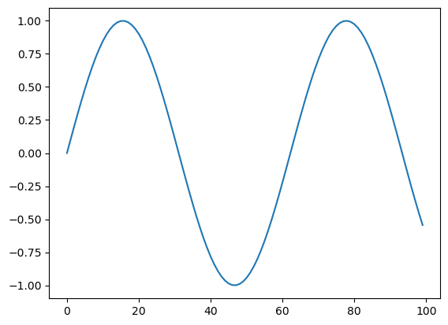

```python
plt.figure()

plt.subplot(1, 1, 1)

### Step 3: Populate data within AXES contained in a FIGURE
plt.plot(np.sin(np.linspace(0, 10, 100)))
```

SHOWING the plot removes the weird text that gets displayed to the screen.

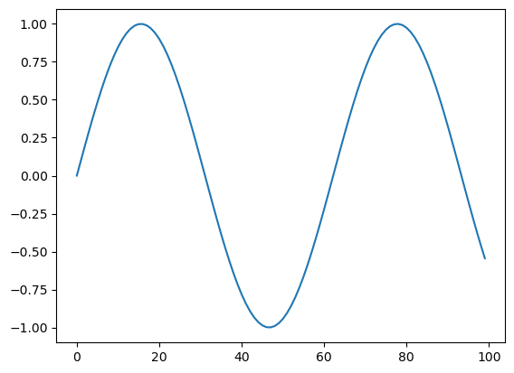

```python
plt.figure()

plt.subplot(1, 1, 1)

plt.plot(np.sin(np.linspace(0, 10, 100)))

plt.show()
```

The odd MATLAB style workflow comes into play...

```python
plt.gcf()
```

```python
plt.gca()
```

Why am i making a big deal about the FIGURE vs SUBPLOT (AXES)????

Because we can have multiple subplots associated with a single figure!!!

Lets initiate a single figure that has 2 subplots. One shows the SINE WAVE and another shows a COSINE wave

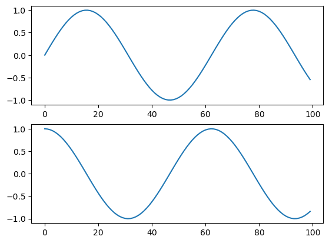

```python
plt.figure()

### Define 2 subplots contained in this figure
plt.subplot(2, 1, 1)

plt.plot(np.sin(np.linspace(0, 10, 100)))

### Define the second subplot within the figure
plt.subplot(2, 1, 2)

plt.plot(np.cos(np.linspace(0, 10, 100)))

plt.show()
```

Examine this again but only populate data on the 2nd subplot.

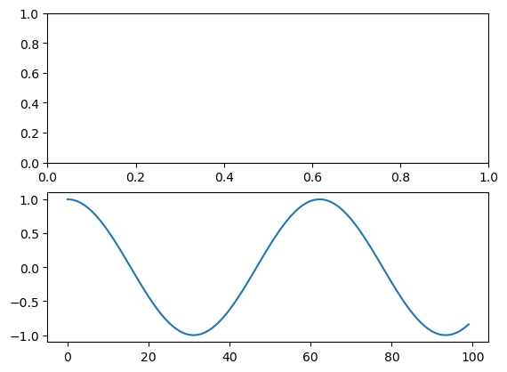

```python
plt.figure()

plt.subplot(2, 1, 1)

plt.subplot(2, 1, 2)

plt.plot(np.cos(np.linspace(0, 10, 100)))

plt.show()
```

We could instead use 1 row and 2 columns of subplots.

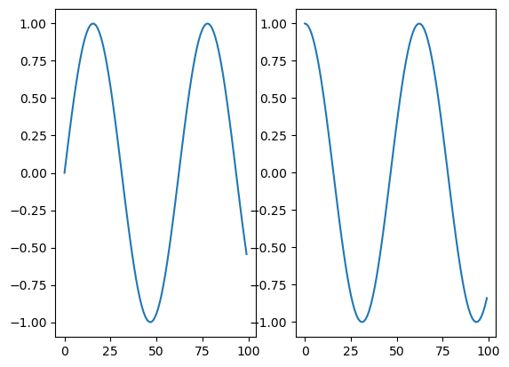

```python
plt.figure()

plt.subplot(1, 2, 1)

plt.plot(np.sin(np.linspace(0, 10, 100)))

plt.subplot(1, 2, 2)

plt.plot(np.cos(np.linspace(0, 10, 100)))

plt.show()
```

We can control the exact AXES or subplot the data are populated to!

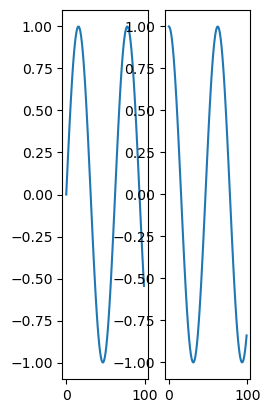

```python
plt.figure()

plt.subplot(1, 5, 1)

plt.plot(np.sin(np.linspace(0, 10, 100)))

plt.subplot(1, 5, 2)

plt.plot(np.cos(np.linspace(0, 10, 100)))

plt.show()
```

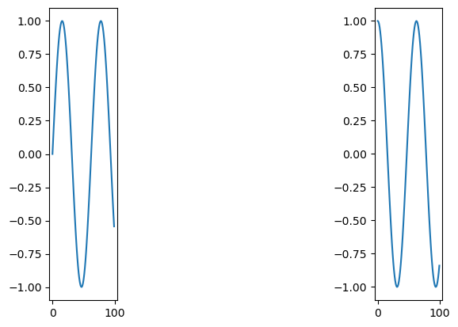

```python
plt.figure()

plt.subplot(1, 5, 1)

plt.plot(np.sin(np.linspace(0, 10, 100)))

plt.subplot(1, 5, 5)

plt.plot(np.cos(np.linspace(0, 10, 100)))

plt.show()
```

We can control the figure size with the figsize argument to the plt.figure() function!

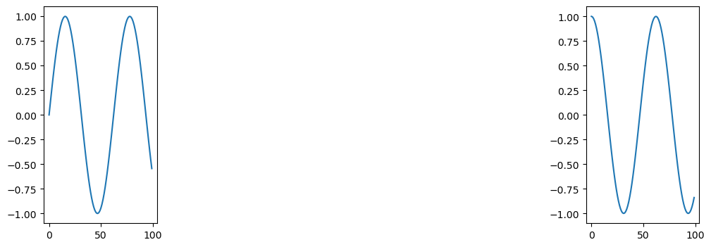

```python
plt.figure(figsize=(12,4))

plt.subplot(1, 5, 1)

plt.plot(np.sin(np.linspace(0, 10, 100)))

plt.subplot(1, 5, 5)

plt.plot(np.cos(np.linspace(0, 10, 100)))

plt.show()
```

## Object Oriented Style

Many aspets of the object oriented style figures are the same as the STATEFUL figures. But the way we access or apply functions to them are different!

- Step 1: Define the figure and axes objects - create variables!
- Step 2: Plot the data within the axes using methods associated with the axes objects!
- Step 3: Modify the axes object attributes if needed
- Step 4: Modify the figure object attributes if needed
- Step 5: Show the figure

The motivation for the object oriented approach is that the STATEFUL approach works with the HIDDEN OBJECTS!!!

Define variables or objets for the FIGURE and AXES that we are modifying!!

The common names for these objects are fig and ax.

```python
%whos
```

```
Variable   Type      Data/Info
------------------------------
np         module    <module 'numpy' from '/Ap<...>kages/numpy/__init__.py'>
pd         module    <module 'pandas' from '/A<...>ages/pandas/__init__.py'>
plt        module    <module 'matplotlib.pyplo<...>es/matplotlib/pyplot.py'>
```

```python
fig, ax = plt.subplots()
```

```python
type(fig)
```

```
matplotlib.figure.Figure
```

```python
type(ax)
```

```
matplotlib.axes._axes.Axes
```

The same approach is used even if we want MULTIPLE axes or subplots within a single figure.

Lets create 2 suplots below.

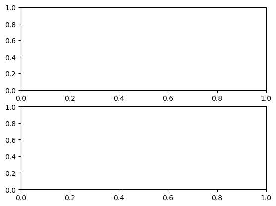

```python
fig, ax = plt.subplots(2)
```

```python
%whos
```

```
Variable   Type       Data/Info
-------------------------------
ax         ndarray    2: 2 elems, type `object`, 16 bytes
fig        Figure     Figure(640x480)
np         module     <module 'numpy' from '/Ap<...>kages/numpy/__init__.py'>
pd         module     <module 'pandas' from '/A<...>ages/pandas/__init__.py'>
plt        module     <module 'matplotlib.pyplo<...>es/matplotlib/pyplot.py'>
```

```python
type(ax)
```

```
numpy.ndarray
```

```python
ax.size
```

```
2
```

```python
ax.shape
```

```
(2,)
```

```python
type(ax[0])
```

```
matplotlib.axes._axes.Axes
```

```python
ax
```

```
array([<Axes: >, <Axes: >], dtype=object)
```

```python
ax[0]
```

We populate data or plot the data by calling the METHOD for the corresponding axes element@@

```python
ax[0].plot(np.sin(np.linspace(0, 10, 100)))
```

```python
ax[1].plot(np.cos(np.linspace(0, 10, 100)))
```

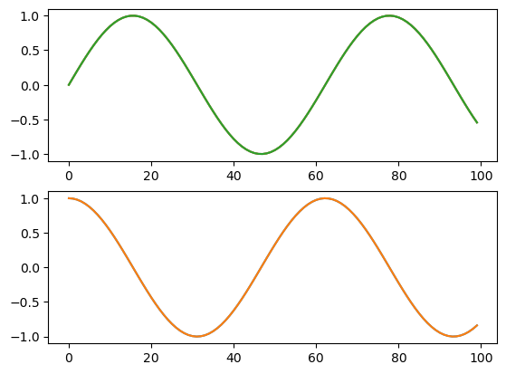

```python
fig
```

We have a lot of control over the subplots or axes within a figure.

Lets make a figure with 2 rows and 3 columns of subplots.

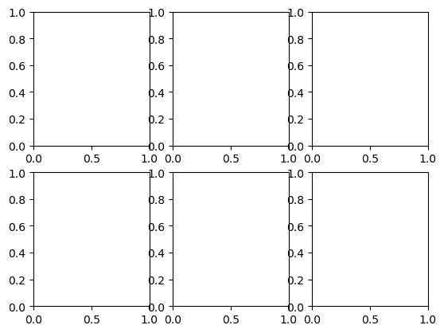

```python
fig, ax = plt.subplots(2, 3)
```

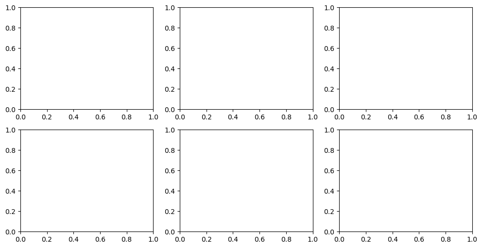

```python
fig, ax = plt.subplots(2, 3, figsize=(12,6))
```

We can force each subplot to SHARE axes!!

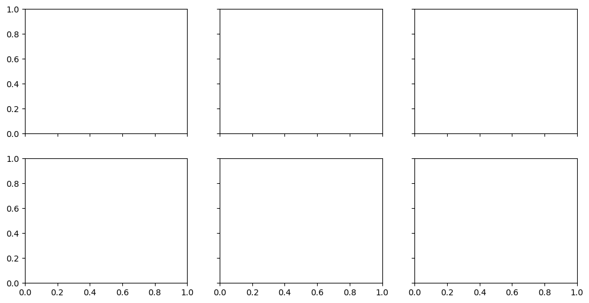

```python
fig, axs = plt.subplots(2, 3, figsize=(12, 6), sharex=True, sharey=True)
```

```python
type(axs)
```

```
numpy.ndarray
```

```python
axs.shape
```

```
(2, 3)
```

We can slice a 2D array just like we slice any 2D numpy array!

```python
axs[0, 0]
```

Use a nested for loop to iterate over each subplot within the figure and display some text.

```python
for i in range(axs.shape[0]):
    for j in range(axs.shape[1]):
        axs[i, j].text(0.5, 0.5, str((i, j)), ha="center",fontsize=20)
```

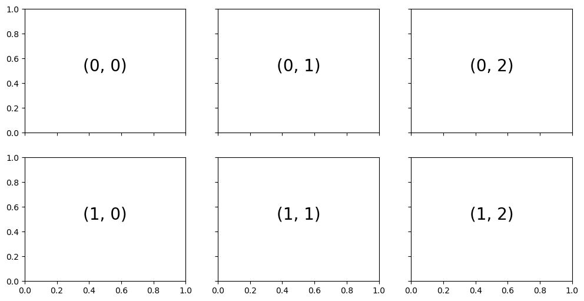

```python
fig
```

Put everything in a single cell.

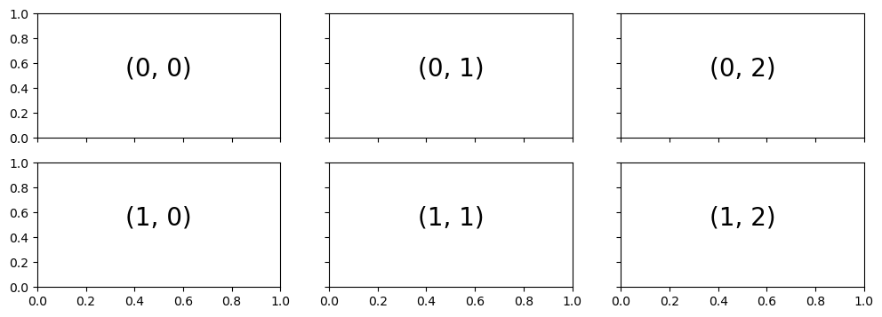

```python
fig, axs = plt.subplots(2, 3, figsize=(12,4), sharex=True, sharey=True)

for i in range(axs.shape[0]):
    for j in range(axs.shape[1]):
        axs[i, j].text(0.5, 0.5, str((i, j)), ha="center",fontsize=20)

plt.show()
```